# Творческая работа

# Введение

Мутность воды является важным показателем её качества, а также характеристикой стока взвешенных наносов. По этой причине наблюдения за мутностью важны как для оценки экологического состояния водных объектов, так и для характеристики эрозионных процессов на водосборе и в русле реки. Целью данной работы является изучение краткосрочных (турбулентных) колебаний мутности воды на примере реки Сетунь. В соответствие с этой целью были решены следующие задачи:

1. Чтение и подготовка данных наблюдений, полученных с автоматических логгеров;
2. Осреднение данных и приведение к регулярной временной сетке;
3. Статистическая оценка данных наблюдений;
4. Построение карты расположения постов наблюдений за уровнями воды и мутностью в бассейне реки Сетунь;
5. Построение карты пунктов, для которых с помощью автоматических логгеров получены ряды наблюдений за краткосрочными колебаниями мутности воды.

# Импорт пакетов

```r
library(tidyverse)
library(readxl)
library(lubridate)
library(tsibble)
```

```r
library(ggplot2)
library(Kendall)
library(tmap)
library(tmaptools)
library(sf)
library(rnaturalearth)
library(ggrepel)
```

# Чтение и подготовка данных

## Данные наблюдений за мутностью воды в бассейне реки Сетунь

Данные с автоматических логгеров разбиты по нескольким файлам, формат которых не всегда совпадает. Данные наблюдений были считаны из каждого файла отлельно и затем собраны в единый ряд. Примечание: данные в некоторых местах содержат пропуски, что связано с особенностями работы логгера, а также технические пометки. При преобразованиях в данных строках создаются NA, которые удаляются из датафрейма функцией na.omit.

```r
data1 <- read_csv('data/turbidity/VuSitu_2020-11-24_12-43-49_Сетунь_Журнал регистрации_Сетунь 24_11_2020-2.csv',
                  skip = 23,
                  show_col_types = F) |>
        select(1:2) |>
        na.omit() |>
        mutate(`Дата и время` = as.POSIXct(`Дата и время`)) |>
        magrittr::set_colnames(c('dt', 'turbidity'))
data2 <- read_xlsx('data/turbidity/t_setun_20191116-20200130.xlsx',
                    sheet = 3,
                    col_types = c('date', 'numeric', rep('skip', 10)),
                    col_names = c('dt', 'turbidity')) |>
        na.omit()
data3 <-  read_log('data/turbidity/setun_19032020.log',
                   skip = 29,
                   show_col_types = F) |>
            separate(col = X1,
                     into = c('DATE', 'TIME', 'turbidity', 'units', NA, NA, NA),
                     sep = '_') |>
            mutate(dt = paste(DATE, TIME) |> as_datetime()) |>
            select(dt, turbidity) |>
            na.omit() |>
            mutate(turbidity = as.numeric(turbidity)) |>
            na.omit()
data4 <- read_xlsx('data/turbidity/temp/079851_20200320_1056.xlsx',
                    sheet = 3,
                    skip = 1) |>
          na.omit() |>
          magrittr::set_colnames(c('dt', 'turbidity'))

data5 <- read_csv('data/turbidity/temp/VuSitu_2020-03-19_16-44-08_Сетунь_Журнал регистрации_Журнал_2020-3-19.csv',
               skip = 23,
               show_col_types = F) |>
        select(1:2) |>
        na.omit() |>
        magrittr::set_colnames(c('dt', 'turbidity')) |>
        mutate(dt = as.POSIXct(dt)) |>
        na.omit()
# собираем всё в один датафрейм:
data_turb <- rbind(data1, data2, data3, data4, data5) |>
  arrange(dt) |>
  as_tsibble(index = dt)
```

## Данные наблюдений за расходами воды в бассейне реки Сетунь

В бассейне реки ведутся автоматические наблюдения за уровнем воды. По известной зависимости расхода воды от уровня был получен ряд расходов с частотой 30 минут.

```r
data_Q <- read_xlsx('data/Сетунь_низ_уровни.xlsx',
                    sheet = 'Сетунь3', skip = 5) |>
  select(1, 8) |>
  magrittr::set_colnames(c('dt', 'Q')) |>
  as_tsibble(index = dt)
```

## Объединение датафреймов и приведение к единой временной шкале

Ряд данных наблюдений за мутностью и расходами воды необходимо привести к единой временной сетке с шагом 30 минут. Для каждого ряда определим максимальное и минимальное время измерений и округлим их до ближайшего времени, кратного 30 минутам. Затем сформируем последовательность временных срезов между полученными границами 30-минутных серий и проинтерполируем величины расхода и мутности на новую сетку. Продолжительность интерполируемого интервала не должна превышать 60 минут. Для ряда расходов:

```r
tmin <- ceiling_date(min(data_Q$dt), unit = '30 minutes')
tmax <- floor_date(max(data_Q$dt), unit = '30 minutes')

Q_interp <- tibble(
  datetime = seq(tmin, tmax, by = '30 min'),
  Q = round(approx(data_Q$dt, data_Q$Q, xout = datetime)$y, 1)
)

idx <- sapply(Q_interp$datetime, \(x) match(TRUE, data_Q$dt >= x))

Q_interp <- Q_interp |>
  mutate(before_time = datetime - data_Q$dt[idx-1],
         after_time = data_Q$dt[idx] - datetime,
         valid = after_time - before_time <= minutes(60))
cat('Valid are ', round(100 * sum(Q_interp$valid) / nrow(Q_interp), 1),
    '% of interpolated values', sep = '')
```

```
## Valid are 100% of interpolated values
```

Данные о расходах воды теперь приведены к регулярной временной сетке 30 минут. Все интерполированные значения уложились в порог 60 минут.

Для мутности воды:

```r
tmin <- ceiling_date(min(data_turb$dt), unit = '30 minutes')
tmax <- floor_date(max(data_turb$dt), unit = '30 minutes')

turb_interp <- tibble(
  datetime = seq(tmin, tmax, by = '30 min'),
  turbidity = round(approx(data_turb$dt,
                           data_turb$turbidity,
                           xout = datetime)$y, 1)
)

idx <- sapply(turb_interp$datetime, \(x) match(TRUE, data_turb$dt >= x))

turb_interp <- turb_interp |>
  mutate(before_time = datetime - data_turb$dt[idx-1],
         after_time = data_turb$dt[idx] - datetime,
         valid = after_time + before_time <= minutes(60))

cat('Valid are ', round(100 * sum(turb_interp$valid) / nrow(turb_interp), 1),
    '% of interpolated values', sep = '')
```

```
## Valid are 38% of interpolated values
```

Данные о мутности теперь тоже приведены к единой временной сетке, однако они содержат значительные временные разрывы. Заполним строки, в которых продолжительность интерполируемого интервала превышала 60 минут (в них столбец valid равен FALSE), значениями NA, а затем проанализируем пропуски:

```r
turb_interp <- mutate(turb_interp, turbidity = ifelse(valid, turbidity, NA))

# функция для нахождения пропусков во временном ряду
find_gaps = function(df, variable) {
  df |>
    as_tibble() |>
    mutate(type = if_else(is.na(df[variable]), 'gap', 'data'),
           num = with(rle(type), rep(seq_along(lengths), lengths))) |>
    group_by(num) |>
    summarise(start_date = min(datetime),
              end_date = max(datetime),
              duration = end_date - start_date + 1,
              type = first(type))
}

find_gaps(turb_interp, 'turbidity')
```

| num | start_date | end_date | duration | type |
| --- | --- | --- | --- | --- |
| 1 | 2019-11-16 15:30:00 | 2020-03-20 13:30:00 | 125.91667 days | data |
| 2 | 2020-03-20 14:00:00 | 2020-11-24 12:30:00 | 249.93750 days | gap |
| 3 | 2020-11-24 13:00:00 | 2020-12-11 08:30:00 | 17.81250 days | data |
| 4 | 2020-12-11 09:00:00 | 2021-01-25 15:30:00 | 46.27083 days | gap |
| 5 | 2021-01-25 16:00:00 | 2021-03-05 10:00:00 | 39.75000 days | data |

По таблице видно, что наблюдения за мутностью проводились в периоды с 16 ноября 2019 г. по 20 марта 2020 г., с 24 ноября 2020 г. по 11 декабря 2020 г. и с 25 января 2021 г. по 5 марта 2021 г. Ряд разделяют на три части значительные временные разрывы. Объединим ряды мутности и расходов воды и рассчитаем основные статистические характеристики:

```r
# объединяем в один датафрейм
df <- inner_join(Q_interp, turb_interp, by = "datetime") |>
  select(datetime, Q, turbidity) |>
  filter(!is.na(turbidity))
```

Рассчитаем средние, стандартные отклонения, разброс, коэффициент вариации, наличие или отсутствие статистически значимого монотонного тренда (тест Манна- Кендалла) для расхода и мутности. Для мутности также рассчитаем индексы ψ и ζ. Индекс ψ определяется формулой $\psi = \bigg|\frac{1}{n-1}\sum\limits_{i=1}^{n-1}(x_{i+1} - x_i)\bigg|$ где $x_{i+1}$ и ${x_i}$ - соседние измерения мутности. Данный индекс отражает величину быстрых изменений мутности и характеризует её турбулентные колебания. Индекс ζ определяется формулой $\zeta = \frac{\psi}{\max x_i - \min x_i}$ Данный индекс характеризует выраженность турбулентных колебаний мутности на фоне её общих флуктуаций и является мерой соотношения турбулентных и синоптических колебаний.

```r
df |>
  summarize(Q_mean = mean(Q),
            Q_range = max(Q) - min(Q),
            Q_sd = sd(Q),
            Q_cv = Q_sd / Q_mean,
            Q_trend_tau = MannKendall(Q)$tau[1],
            Q_trend_p = MannKendall(Q)$sl[1],
            turb_mean = mean(turbidity),
            turb_range = max(turbidity) - min(turbidity),
            turb_sd = sd(turbidity),
            turb_cv = turb_sd / turb_mean,
            turb_trend_tau = MannKendall(turbidity)$tau[1],
            turb_trend_p = MannKendall(turbidity)$sl[1],
            psi = abs(sum(lag(turbidity, 1) - turbidity,
                        na.rm = T) / (nrow(df) - 1)),
            zeta = psi / turb_range) |>
  pivot_longer(cols = everything(), names_to = 'metric', values_to = 'value')
```

| metric | value |
| --- | --- |
| Q_mean | 2.680250e+00 |
| Q_range | 5.200000e+00 |
| Q_sd | 4.563977e-01 |
| Q_cv | 1.702818e-01 |
| Q_trend_tau | 3.146444e-01 |
| Q_trend_p | 0.000000e+00 |
| turb_mean | 1.277546e+02 |
| turb_range | 9.030000e+02 |
| turb_sd | 1.522650e+02 |
| turb_cv | 1.191856e+00 |

[output cut: 4 more lines]

Вычисленные характеристики можно использовать для дальнейшего сопоставления с другими постами наблюдений. Построим графики плотности распределения расхода воды и мутности:

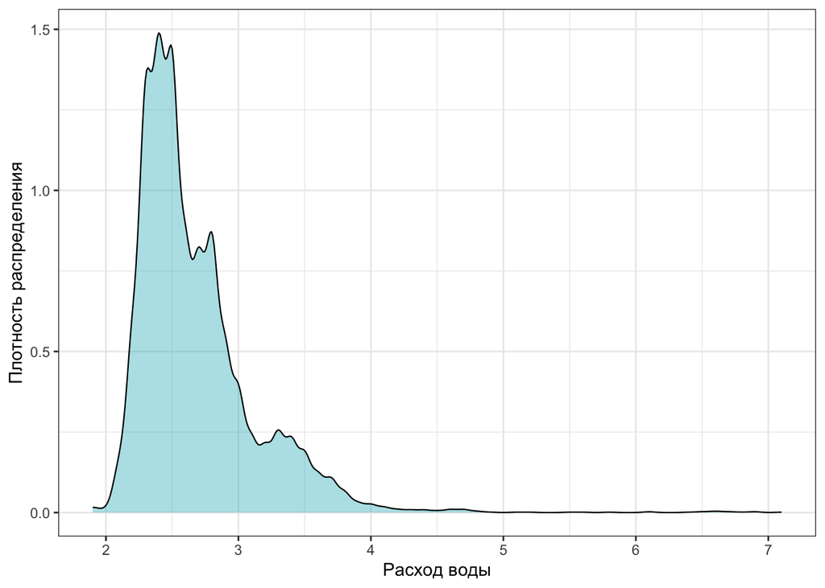

```r
# расход воды
ggplot(data = df, aes(x = Q)) +
  geom_density(linewidth = .4, fill = '#31b8c4', alpha = .4) +
  labs(x = 'Расход воды', y = 'Плотность распределения') +
  theme_bw()
```

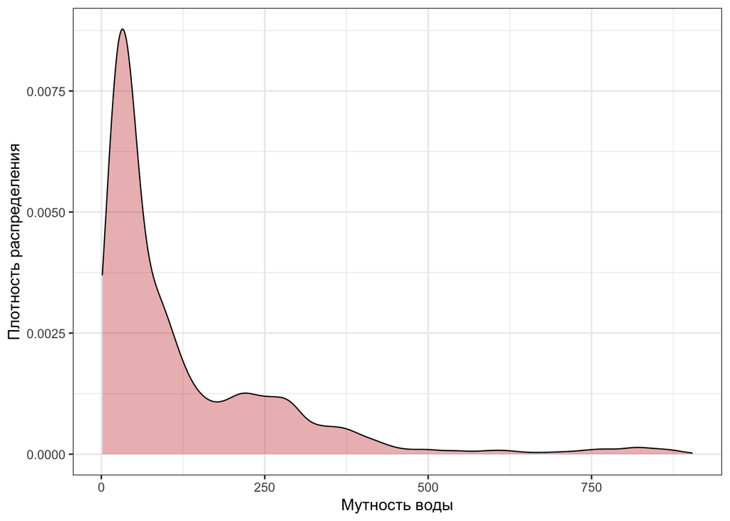

```r
# мутность
ggplot(data = df, aes(x = turbidity)) +
  geom_density(linewidth = .4, fill = '#cd4a4c', alpha = .4) +
    labs(x = 'Мутность воды', y = 'Плотность распределения') +
  theme_bw()
```

Расход воды не является надёжным предиктором мутности, однако всё же рассмотрим коэффициенты корреляции между мутностью и расходом в то же время и взятым с некоторым временным лагом:

```r
df |>
  summarize(
    cor0 = cor(turbidity, Q),    # без сдвига по времени
    cor10 = cor(turbidity, lag(Q, 10),
              use = 'complete.obs'),    # сдвиг на 10 наблюдений
    cor20 = cor(turbidity, lag(Q, 20),
              use = 'complete.obs'),    # сдвиг на 20 наблюдений
    cor30 = cor(turbidity, lag(Q, 30),
              use = 'complete.obs'),    # сдвиг на 30 наблюдений
    cor40 = cor(turbidity, lag(Q, 40),
              use = 'complete.obs')    # сдвиг на 40 наблюдений
  ) |>
  pivot_longer(cols = everything(), names_to = 'metric', values_to = 'value')
```

| metric | value |
| --- | --- |
| cor0 | 0.10859160 |
| cor10 | 0.09407905 |
| cor20 | 0.08700948 |
| cor30 | 0.07135643 |
| cor40 | 0.06662029 |

Как и предполагалось, корреляции между показателями не наблюдается.

# Построение карты расположения постов наблюдений в бассейне реки Сетунь

По известным координатам пунктов наблюдений создадим слой точек:

```r
loggers <- matrix(c(
  55.729943, 37.529679, 'уровень воды',
  55.709917, 37.452927, 'уровень воды',
  55.696543, 37.397338, 'уровень воды',
  55.729085, 37.536159, 'мутность воды',
  55.714330, 37.444141, 'мутность воды'
), ncol = 3, byrow = T) |>
  data.frame() |>
  magrittr::set_colnames(c('lat', 'lon', 'тип логгера')) |>
  mutate(lat = as.numeric(lat), lon = as.numeric(lon)) |>
  st_as_sf(coords = c('lon', 'lat'), crs = 4326)
```

По слою точек построим интерактивную карту:

```r
tmap_mode('view')
```

```
## tmap mode set to interactive viewing
```

```r
tmap_options(check.and.fix = TRUE)

tm_basemap('OpenStreetMap') +
  tm_shape(loggers) +
  tm_dots(col = 'тип логгера', size = .07, palette = get_brewer_pal("Set1", n = 2, plot = F))
```

[interactive chart not shown]

# Построение карты пунктов наблюдений за мутностью воды

Построим карту пунктов, для которых с помощью автоматических логгеров получены ряды наблюдений за краткосрочными колебаниями мутности воды. Получим слои точек из шейп-файлов:

```r
shp1 <- st_read('data/loggers_shp/loggery_ot_SR/loggery_ot_SR.shp', quiet = T)
shp2 <- st_read('data/loggers_shp/turb_stations/turb_stations.shp', quiet = T)
```

Получим слои стран, океана, береговой линии и т.п. для отображения на карте:

```r
countries <- ne_countries(scale = 50, returnclass = 'sf')
coast <- ne_coastline(scale = 50, returnclass = 'sf')
ocean <- ne_download(scale = 50,
                    type = 'ocean',
                    category = 'physical',
                    returnclass = 'sf')
rivers <- ne_download(scale = 50,
                     type = 'rivers_lake_centerlines',
                     category = 'physical',
                     returnclass = 'sf')
lakes <- ne_download(scale = 50,
                    type = 'lakes',
                    category = 'physical',
                    returnclass = 'sf')
borders <- ne_download(scale = 50,
                       type = 'admin_0_boundary_lines_land',
                       returnclass = 'sf')

lyr50 = lst(ocean, coast, countries,
             rivers, lakes, borders)
```

Построение карты:

```
## Scale on map varies by more than 10%, scale bar may be inaccurate
```

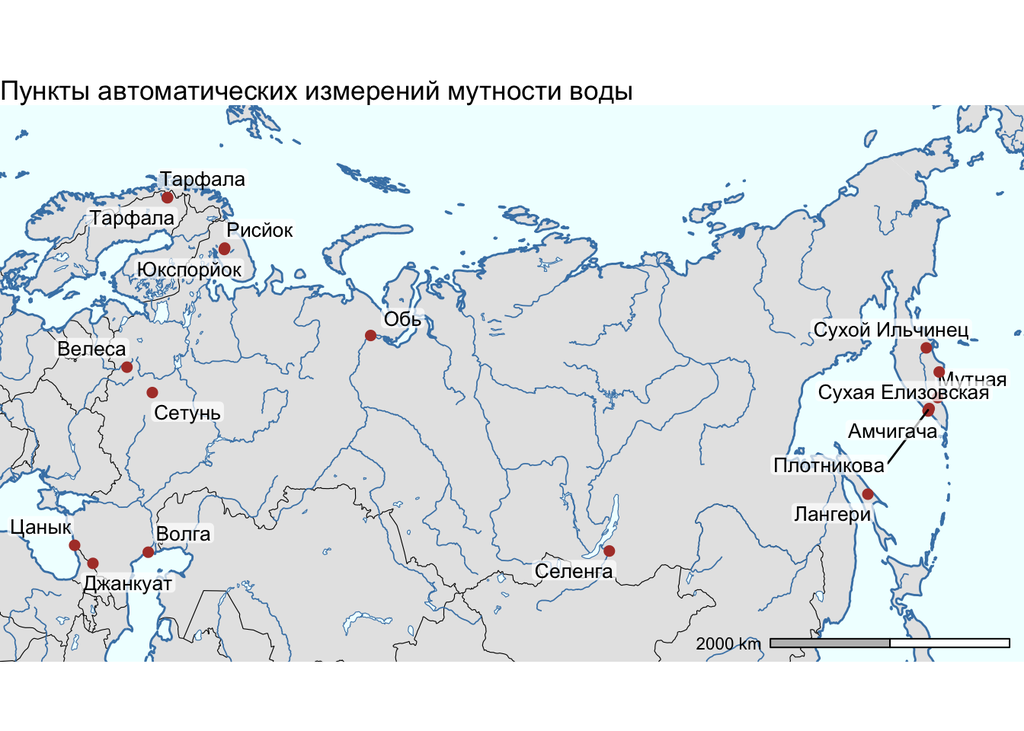

```r
# код проекции
proj <- '+proj=aea +lat_0=30 +lon_0=95 +lat_1=15 +lat_2=65 +x_0=0 +y_0=0 +datum=WGS84 +units=m +no_defs +type=crs'

# создаём ограничивающий прямоугольник, чтобы затем задать по нему границы карты
box <- st_bbox(lyr50$countries |>
                 filter(admin == 'Russia') |>
                 st_transform(crs = proj))

ggplot() +
  geom_sf(data = lyr50$countries, color = NA) +
  geom_sf(data = lyr50$borders, linewidth = .2) +
  geom_sf(data = lyr50$ocean,
          fill = 'azure', color = NA) +
  geom_sf(data = lyr50$coast,
          size = .2, color = 'steelblue') +
  geom_sf(data = lyr50$rivers, color = 'steelblue', linewidth = .3) +
  geom_sf(data = lyr50$lakes, fill = 'azure', color = 'steelblue') +
  geom_sf(data = shp1, color = '#b03f35', size = 2) +
  geom_label_repel(data = shp1,
                   stat = "sf_coordinates",
                   aes(label = podpis, geometry = geometry),
                   size = 3.5,
                   label.size = NA,
                   label.padding = .1,
                   fill = alpha("white", 0.7)) +
  geom_sf(data = shp2, color = '#b03f35', size = 2) +
  geom_label_repel(data = shp2,
                   stat = "sf_coordinates",
                   aes(label = Река, geometry = geometry),
                   size = 3.5,
                   label.size = NA,
                   label.padding = .1,
                   fill = alpha("white", 0.7)) +
  coord_sf(crs = proj,
           xlim = c(box[1], box[3]),
           ylim = c(box[2], box[4])) +
  theme_void() +
  ggspatial::annotation_scale(bar_cols = c('gray', 'white'),
                   location = 'br',
                   height = unit(.15, "cm")) +
  labs(title = 'Пункты автоматических измерений мутности воды')
```